# 📊 Análise e Previsão da População Brasileira

## 1. Introdução

Este notebook apresenta um fluxo completo de análise de dados da população brasileira utilizando dados disponibilizados pelo Instituto Brasileiro de Geografia e Estatística (IBGE).

O projeto tem como objetivo demonstrar, de forma reprodutível, as principais etapas de um processo de Data Science:

- consumo de uma API pública;
- extração de dados com `requests`;
- transformação da resposta JSON;
- construção de um DataFrame com `pandas`;
- validação e tratamento dos dados;
- análise exploratória;
- preparação das variáveis;
- separação entre treinamento e teste;
- treinamento de um modelo de regressão polinomial de segundo grau com valores temporais aleatórios;
- avaliação do modelo;
- análise dos resíduos;
- treinamento de um modelo de regressão polinomial de segundo grau com valores temporais não aleatórios;
- comparação entre valores aleatórios e não aleatórios.

### Objetivo

Investigar a relação entre o ano e a população brasileira e construir um modelo de regressão capaz de estimar a população a partir do ano.

> **Importante:** a regressão utilizada neste notebook tem finalidade educacional e analítica. Ela não substitui projeções demográficas oficiais, que consideram variáveis demográficas muito mais complexas.

### Tecnologias

- Python
- Requests
- Pandas
- Matplotlib
- Scikit-learn

### Fonte dos dados

Os dados são obtidos através de uma API pública disponibilizada pelo IBGE.

## 📚 2. Bibliotecas

```python
import requests
import pandas as pd
import matplotlib.pyplot as plt

from sklearn.model_selection import train_test_split # Modelagem e avaliação estatística
from sklearn.linear_model import LinearRegression
from sklearn.preprocessing import PolynomialFeatures
from sklearn.pipeline import make_pipeline
from sklearn.metrics import (
    mean_absolute_error,
    mean_squared_error,
    r2_score,
)
```

## ⚙️ 3. Configuração da API

```python
# A URL da API é definida separadamente para facilitar sua manutenção.
BASE_URL = (
    "https://servicodados.ibge.gov.br/api/v1/"
    "paises/BR/indicadores/77849"
)

TIMEOUT = 30
```

## 📡 4. Requisição HTTP

```python
# A biblioteca `requests` será utilizada para realizar uma requisição HTTP à
# API do IBGE.

try:
    response = requests.get(
        BASE_URL,
        timeout=TIMEOUT,
    )

    response.raise_for_status()

    data = response.json()

except requests.exceptions.Timeout:
    raise RuntimeError("A API excedeu o tempo limite.")

except requests.exceptions.HTTPError as exc:
    raise RuntimeError(
        f"Erro HTTP ao consultar a API: {exc}"
    )

except requests.exceptions.RequestException as exc:
    raise RuntimeError(
        f"Erro de comunicação com a API: {exc}"
    )
```

## 🧹 5. Limpeza

```python
def limpar_serie(serie: list[dict[str, str | None]]) -> list[dict[str, int]]:
    """
    Remove períodos sem valor e converte os valores para inteiros.
    Args:
        serie: Lista de dicionários contendo ano/período e valor.
    Returns:
        Lista contendo somente anos com valores válidos.
    """
    resultado = []

    for item in serie:
        for ano, valor in item.items():
            if valor is not None and ano.isdigit():
                resultado.append(
                    {
                        "ano": int(ano),
                        "valor": int(valor),
                    }
                )

    return resultado
```

## ⚙️ 6. Transformação

```python
# A estrutura relevante:
serie = data[0]["series"][0]["serie"]
# Aplicando a função de transformação
serie_limpa = limpar_serie(serie)
# Transformando DataFrame
df = pd.DataFrame(serie_limpa)
# As observações de 1990 e 1995 foram excluídas para restringir a análise ao período anual contínuo de 2000 a 2023.
df = df[~df["ano"].isin([1990, 1995])]
# Apresentação das primeiros 5 registros do DataFrame
df.head()
```

|  | ano | valor |
| --- | --- | --- |
| 2 | 2000 | 174018282 |
| 3 | 2001 | 176301203 |
| 4 | 2002 | 178503484 |
| 5 | 2003 | 180622688 |
| 6 | 2004 | 182675143 |

## 📊 7. EDA

```python
print(f"Período: {df['ano'].min()}–{df['ano'].max()}")
```

```
Período: 2000–2023
```

```python
df.info()
```

```
<class 'pandas.core.frame.DataFrame'>
Index: 24 entries, 2 to 25
Data columns (total 2 columns):
 #   Column  Non-Null Count  Dtype
---  ------  --------------  -----
 0   ano     24 non-null     int64
 1   valor   24 non-null     int64
dtypes: int64(2)
memory usage: 576.0 bytes
```

### Estrutura dos dados:

o DataFrame contém 24 observações referentes ao período analisado e duas variáveis: ano e valor. Não foram identificados valores ausentes, e ambas as colunas apresentam o tipo int64. A variável ano será utilizada como variável explicativa, enquanto valor representa a variável resposta (população). A estrutura dos dados encontra-se, portanto, adequada para prosseguir com a análise exploratória e avaliar a aplicação de um modelo de regressão polinomial.

```python
estatisticas = df["valor"].describe()
estatisticas = estatisticas.apply(lambda x: f"{x:,.0f}")
print(estatisticas)
```

```
count             24
mean     195,071,078
std       11,589,381
min      174,018,282
25%      186,161,855
50%      196,080,422
75%      205,054,399
max      211,140,729
Name: valor, dtype: object
```

A variável valor apresenta 24 observações, com população média de aproximadamente 195,1 milhões e mediana de 196,1 milhões. Os valores variam entre 174,0 milhões e 211,1 milhões, com desvio-padrão de aproximadamente 11,6 milhões. Os quartis indicam uma distribuição dos valores entre aproximadamente 186,2 milhões e 205,1 milhões para os 50% centrais das observações. Como se trata de uma série temporal, essa dispersão deve ser interpretada considerando a tendência de crescimento populacional ao longo dos anos. Essas informações constituem a etapa descritiva inicial, que será complementada pela análise da relação entre ano e valor para avaliar a aplicação da regressão polinomial.

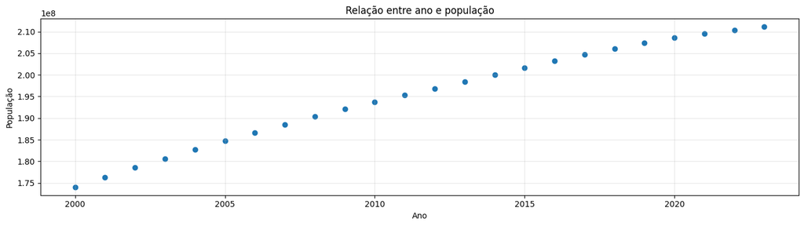

```python
import matplotlib.pyplot as plt

plt.figure(figsize=(14, 4))

plt.scatter(
    df["ano"],
    df["valor"],
)

plt.xlabel("Ano")
plt.ylabel("População")
plt.title("Relação entre ano e população")

plt.grid(True, alpha=0.3)
plt.tight_layout()
plt.show()
```

O gráfico de dispersão evidencia uma relação positiva entre o ano e a população. Os pontos apresentam uma tendência crescente e aproximadamente linear, sugerindo que o avanço dos anos está associado ao aumento da população. Essa característica indica que a regressão polinomial pode ser utilizada como uma primeira abordagem para modelar essa relação, cuja adequação será posteriormente avaliada por meio das métricas do modelo e da análise dos resíduos.

```python
correlacao = df["ano"].corr(df["valor"])
print(f"Correlação: {correlacao:.4f}")
```

```
Correlação: 0.9949
```

A Correlação de Pearson entre as variáveis ano e valor foi de 0,9949, indicando uma associação linear positiva muito forte entre as variáveis. Esse resultado mostra que, no período analisado, os valores de população tendem a aumentar de forma consistente à medida que os anos avançam.

A magnitude do coeficiente, próxima de 1, reforça a tendência aproximadamente linear observada no gráfico de dispersão e fornece uma evidência inicial favorável à utilização da regressão polinomial para modelar a relação entre ano e população.

Entretanto, a correlação elevada não implica, isoladamente, que o modelo de regressão seja adequado nem estabelece uma relação de causalidade. A adequação do modelo deverá ser verificada posteriormente por meio das métricas de ajuste e, principalmente, da análise dos resíduos e dos pressupostos da regressão polinomial.

## 📈 8. Regressão Polinomial de Segundo Grau — Modelo com Divisão Aleatória

```python
# Variáveis utilizadas na regressão
X = df[["ano"]]   # Ano
y = df["valor"]   # Número de habitantes
```

```python
# Divisão dos dados em conjuntos de treinamento e teste
# X_train → dados de entrada para treinamento
# X_test → dados de entrada para teste
# y_train → valores-alvo para treinamento
# y_test → valores-alvo para teste
# test_size=0.2 → 20% para teste e 80% para treinamento
# random_state=42 → garante uma divisão reproduzível

X_train, X_test, y_train, y_test = train_test_split(
    X,
    y,
    test_size=0.2,
    random_state=42,
)
```

```python
# Ajuste de uma regressão polinomial de 2º grau
# make_pipeline(...) → combina as etapas em um pipeline.
# PolynomialFeatures(degree=2) → cria os termos polinomiais.
# LinearRegression() → modelo de regressão polinomial aplicado aos termos transformados.
# .fit(X_train, y_train) → treina/ajusta o modelo.

modelo = make_pipeline(
    PolynomialFeatures(degree=2),
    LinearRegression()
)

modelo.fit(X_train, y_train)
```

```
Pipeline(steps=[('polynomialfeatures', PolynomialFeatures()),
                ('linearregression', LinearRegression())])
```

```python
# Previsões no conjunto de teste
# X_test → anos que o modelo não utilizou no treinamento.
# modelo.predict(X_test) → população prevista para esses anos.
# y_pred → valores previstos.

y_pred = modelo.predict(X_test)
print(y_pred)
```

```
[1.90310033e+08 2.03118076e+08 1.74126350e+08 2.05792643e+08
 1.95508631e+08]
```

## 📑 8.1 Avaliação — Modelo com Divisão Aleatória

```python
mae = mean_absolute_error(y_test, y_pred)
mse = mean_squared_error(y_test, y_pred)
r2 = r2_score(y_test, y_pred)

print(f"MAE: {mae:.2f}")
print(f"MSE: {mse:.2f}")
print(f"R²: {r2:.4f}")
print("====================================================")
print("COMPARAÇÃO ENTRE VALORES REAIS, PREVISTOS, ERROS, ERROS ABSOLUTOS e ERROS PERCENTUAIS")
resultado = pd.DataFrame({"real": y_test,"previsto": y_pred})
resultado["erro"] = (resultado["real"] - resultado["previsto"])
resultado["erro_absoluto"] = (resultado["erro"].abs())
resultado["erro_percentual"] = (resultado["erro_absoluto"] / resultado["real"]) * 100
print(resultado.head(10))
print("====================================================")
# desempenho no treino
print("DESEMPENHO DO TREINO")
r2_train = modelo.score(X_train, y_train)
r2_test = modelo.score(X_test, y_test)
print("R² treino:", r2_train)
print("R² teste:", r2_test)
print("====================================================")
import numpy as np

rmse = np.sqrt(mse)

print(f"RMSE: {rmse:,.2f}")
```

```
MAE: 160778.25
MSE: 34816141824.88
R²: 0.9997
====================================================
COMPARAÇÃO ENTRE VALORES REAIS, PREVISTOS, ERROS, ERROS ABSOLUTOS e ERROS PERCENTUAIS
         real      previsto           erro  erro_absoluto  erro_percentual
10  190367302  1.903100e+08   57269.491608   57269.491608         0.030084
18  203218114  2.031181e+08  100038.214722  100038.214722         0.049227
2   174018282  1.741264e+08 -108068.046936  108068.046936         0.062102
20  206107261  2.057926e+08  314618.018082  314618.018082         0.152648
13  195284734  1.955086e+08 -223897.454163  223897.454163         0.114652
====================================================
DESEMPENHO DO TREINO
R² treino: 0.9996761104345883
R² teste: 0.9997303055208473
====================================================
RMSE: 186,590.84
```

Os resultados obtidos indicam um desempenho elevado do modelo de regressão na estimativa da população. O **MAE (Mean Absolute Error)** foi de aproximadamente **160.778 habitantes**, indicando que, em média, as previsões diferiram dos valores reais em cerca de 161 mil habitantes. Considerando que a população analisada está na ordem de centenas de milhões de habitantes, esse erro representa uma pequena diferença relativa.

O **RMSE (Root Mean Squared Error)** foi de aproximadamente **186.591 habitantes**. Como o RMSE atribui maior peso aos erros mais elevados, seu valor superior ao MAE indica a existência de algumas previsões com erros relativamente maiores, embora ainda pequenos em relação à magnitude da variável analisada.

O modelo apresentou **R² de aproximadamente 0,9997 no conjunto de teste**, enquanto o R² no treinamento foi de aproximadamente **0,9997**. Esses valores indicam que o modelo consegue explicar praticamente toda a variação observada na população dentro dos dados analisados. A proximidade entre os valores de R² de treinamento e teste também não indica uma diferença relevante de desempenho entre os dois conjuntos, sugerindo boa consistência do ajuste para essa amostra.

A comparação entre os valores reais e previstos mostra erros individuais relativamente pequenos. O menor erro absoluto observado foi de aproximadamente **57.269 habitantes**, enquanto o maior foi de aproximadamente **314.618 habitantes**. Os erros percentuais variaram entre aproximadamente **0,03% e 0,15%**, demonstrando que, para todas as observações do conjunto de teste, as previsões ficaram muito próximas dos valores reais.

De forma geral, os resultados mostram que o modelo apresentou excelente ajuste aos dados utilizados na análise. Entretanto, o R² extremamente elevado deve ser interpretado com cautela, especialmente porque o conjunto de dados apresenta uma forte tendência temporal e poucas observações. Portanto, o elevado desempenho observado não deve ser utilizado isoladamente para afirmar que o modelo terá a mesma precisão em períodos futuros ou em dados fora do intervalo analisado.

## 📑 8.2 Análise dos Resíduos — Modelo com Divisão Aleatória

```python
resultado_residuos = pd.DataFrame({
    "ano": X_test["ano"].to_numpy(),
    "real": y_test.to_numpy(),
    "previsto": y_pred,
})

resultado_residuos["residuo"] = (
    resultado_residuos["real"]
    - resultado_residuos["previsto"]
)

resultado_residuos["residuo_absoluto"] = (
    resultado_residuos["residuo"].abs()
)

resultado_residuos = resultado_residuos.sort_values("ano")

resultado_residuos
```

|  | ano | real | previsto | residuo | residuo_absoluto |
| --- | --- | --- | --- | --- | --- |
| 2 | 2000 | 174018282 | 1.741264e+08 | -108068.046936 | 108068.046936 |
| 0 | 2008 | 190367302 | 1.903100e+08 | 57269.491608 | 57269.491608 |
| 4 | 2011 | 195284734 | 1.955086e+08 | -223897.454163 | 223897.454163 |
| 1 | 2016 | 203218114 | 2.031181e+08 | 100038.214722 | 100038.214722 |
| 3 | 2018 | 206107261 | 2.057926e+08 | 314618.018082 | 314618.018082 |

A análise dos resíduos mostra que as previsões do modelo apresentam diferenças relativamente pequenas em relação aos valores observados. Os resíduos variaram de aproximadamente **−223.897 a +314.618 habitantes** nas observações do conjunto de teste.

Os resíduos positivos indicam situações em que o modelo subestimou a população, como no caso da observação de 2018, cujo erro foi de aproximadamente **314.618 habitantes**. Já os resíduos negativos indicam superestimação, como observado em 2000 e 2011.

A presença de resíduos positivos e negativos demonstra que o modelo não apresenta, nessas observações, um erro sempre direcionado para o mesmo lado. Além disso, os erros absolutos são pequenos em relação à população total, que está na ordem de centenas de milhões de habitantes.

Apesar desse resultado favorável, a quantidade reduzida de observações no conjunto de teste limita a capacidade de concluir, de forma definitiva, sobre o comportamento dos resíduos. Por isso, a análise gráfica dos resíduos deve ser utilizada para verificar a existência de padrões sistemáticos, tendências ou agrupamentos que possam indicar limitações no ajuste do modelo.

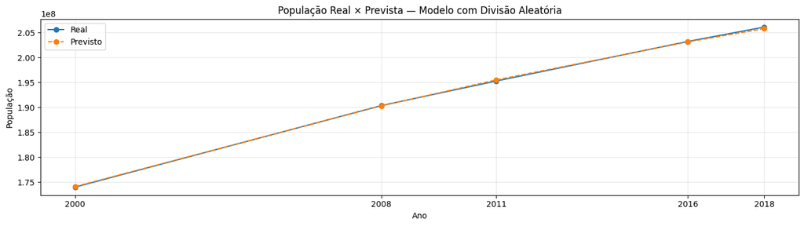

```python
plt.figure(figsize=(14, 4))

plt.plot(
    resultado_residuos["ano"],
    resultado_residuos["real"],
    marker="o",
    label="Real",
)

plt.plot(
    resultado_residuos["ano"],
    resultado_residuos["previsto"],
    marker="o",
    linestyle="--",
    label="Previsto",
)

plt.title("População Real × Prevista — Modelo com Divisão Aleatória")
plt.xlabel("Ano")
plt.ylabel("População")
plt.xticks(resultado_residuos["ano"])
plt.legend()
plt.grid(True, alpha=0.3)

plt.tight_layout()
plt.show()
```

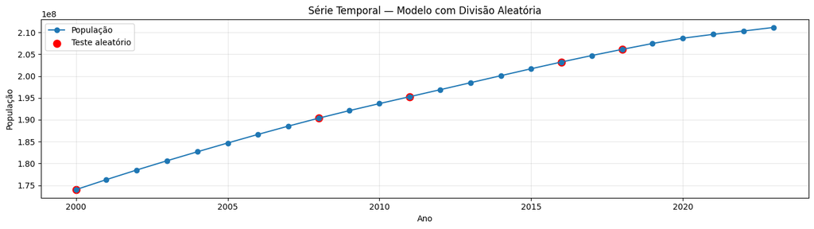

```python
plt.figure(figsize=(14, 4))

plt.plot(
    df["ano"],
    df["valor"],
    marker="o",
    label="População",
)

plt.scatter(
    X_test["ano"],
    y_test,
    s=80,
    color="red",
    label="Teste aleatório",
)

plt.title("Série Temporal — Modelo com Divisão Aleatória")
plt.xlabel("Ano")
plt.ylabel("População")
plt.legend()
plt.grid(True, alpha=0.3)

plt.tight_layout()
plt.show()
```

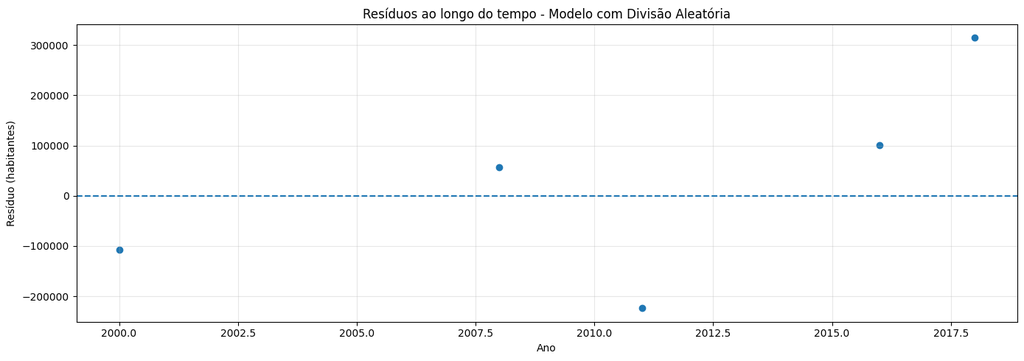

```python
plt.figure(figsize=(14, 5))

plt.scatter(
    resultado_residuos["ano"],
    resultado_residuos["residuo"],
)

plt.axhline(
    y=0,
    linestyle="--",
)

plt.xlabel("Ano")
plt.ylabel("Resíduo (habitantes)")
plt.title("Resíduos ao longo do tempo - Modelo com Divisão Aleatória")

plt.ticklabel_format(
    style="plain",
    axis="y",
)

plt.grid(True, alpha=0.3)
plt.tight_layout()
plt.show()
```

O gráfico de resíduos apresenta a diferença entre os valores observados e os valores estimados pelo modelo ao longo dos anos. Os resíduos variam entre aproximadamente −224 mil e +315 mil habitantes, apresentando valores positivos e negativos em diferentes pontos do período analisado.

A distribuição dos pontos em torno da linha de referência igual a zero indica que o modelo alterna entre superestimar e subestimar os valores observados, sem apresentar, neste conjunto reduzido de observações, um viés sistemático claramente definido. O maior resíduo positivo ocorre em 2018, enquanto o maior resíduo negativo ocorre em 2011.

Também não se observa, de forma evidente, um padrão de dispersão crescente ou decrescente que caracterizaria uma possível heterocedasticidade. Entretanto, a presença de apenas cinco observações no conjunto de teste limita a capacidade de realizar conclusões robustas a partir do gráfico.

Portanto, os resíduos não apresentam um padrão visual claramente problemático, mas essa evidência deve ser interpretada com cautela. Para uma avaliação mais adequada da capacidade preditiva do modelo, especialmente por se tratar de uma série temporal, é preferível utilizar uma separação temporal dos dados, mantendo 2000–2019 para treinamento e 2020–2023 para teste.

## ✅ 8.3 Previsão para 2026 — Modelo com Divisão Aleatória

```python
ano_atual = pd.DataFrame({
    "ano": [2026],
})
```

```python
y_pred_2026 = modelo.predict(ano_atual)
print(f"População estimada pela regressão para 2026: {y_pred_2026[0]:,.0f} habitantes.".replace(",", "."))
print("IBGE - 1º de Julho de 2026: 214.211.951 habitantes")
```

```
População estimada pela regressão para 2026: 214.381.137 habitantes.
IBGE - 1º de Julho de 2026: 214.211.951 habitantes
```

A regressão estimou uma população de **214.381.137 habitantes para 2026**. Esse resultado apresenta uma proximidade considerável com a estimativa oficial divulgada pelo Instituto Brasileiro de Geografia e Estatística (IBGE), que registrou **214.211.951 habitantes em 1º de julho de 2026**.

A diferença entre a previsão do modelo e a estimativa oficial foi de aproximadamente **169.186 habitantes**, o que corresponde a cerca de **0,08%** em relação ao valor observado pelo IBGE. Esse resultado demonstra que o modelo conseguiu reproduzir, com pequena diferença, a magnitude da população brasileira em 2026.

Essa comparação é relevante porque o valor de 2026 não foi utilizado no conjunto histórico empregado para construir a regressão, permitindo avaliar a capacidade do modelo de realizar uma previsão para um período posterior aos dados utilizados na análise. Entretanto, a proximidade entre os valores não deve ser interpretada isoladamente como prova de que o modelo possui elevada capacidade preditiva. É necessário considerar também as métricas de avaliação, os resíduos e os pressupostos da regressão.

Além disso, o próprio IBGE informa que a população brasileira apresentou crescimento de **0,37% entre 2025 e 2026**, indicando uma desaceleração do crescimento populacional. Esse comportamento reforça a importância de avaliar, em análises futuras, se uma relação puramente linear continua adequada para representar a evolução da população em horizontes temporais mais longos.

### Observação:

A previsão apresentou boa proximidade com a estimativa externa observada para 2026.  
É uma validação pontual, não uma validação definitiva do modelo.

## 📈 9. Regressão Polinomial de Segundo Grau — Modelo com Divisão não Aleatória

- Treino: 2000 → 2019
- Teste : 2020 → 2023

```python
# Divisão temporal

X = df[["ano"]]
y = df["valor"]

X_train = X[X["ano"] <= 2019]
X_test = X[X["ano"] >= 2020]

y_train = y[X["ano"] <= 2019]
y_test = y[X["ano"] >= 2020]

print("Treino:", X_train["ano"].min(), "→", X_train["ano"].max())
print("Teste :", X_test["ano"].min(), "→", X_test["ano"].max())

print("Observações de treino:", len(X_train))
print("Observações de teste :", len(X_test))
```

```
Treino: 2000 → 2019
Teste : 2020 → 2023
Observações de treino: 20
Observações de teste : 4
```

```python
# Ajuste de uma regressão polinomial de 2º grau
# make_pipeline(...) → combina as etapas em um pipeline.
# PolynomialFeatures(degree=2) → cria os termos polinomiais.
# LinearRegression() → modelo de regressão polinomial aplicado aos termos transformados.
# .fit(X_train, y_train) → treina/ajusta o modelo.

modelo = make_pipeline(
    PolynomialFeatures(degree=2),
    LinearRegression(),
)

modelo.fit(X_train, y_train)
```

```
Pipeline(steps=[('polynomialfeatures', PolynomialFeatures()),
                ('linearregression', LinearRegression())])
```

```python
# Previsões no conjunto de teste
# X_test → anos que o modelo não utilizou no treinamento.
# modelo.predict(X_test) → população prevista para esses anos.
# y_pred → valores previstos.

y_pred_test = modelo.predict(X_test)
y_pred_test
```

```
array([2.08600569e+08, 2.09829982e+08, 2.11012780e+08, 2.12148962e+08])
```

## 📑 9.1 Avaliação — Modelo com Divisão não Aleatória

```python
mae = mean_absolute_error(y_test, y_pred_test)
mse = mean_squared_error(y_test, y_pred_test)
r2 = r2_score(y_test, y_pred_test)

print(f"MAE: {mae:.2f}")
print(f"MSE: {mse:.2f}")
print(f"R²: {r2:.2f}")
print("====================================================")
print("COMPARAÇÃO ENTRE VALORES REAIS, PREVISTOS, ERROS, ERROS ABSOLUTOS e ERROS PERCENTUAIS")
resultado = pd.DataFrame({"real": y_test,"previsto": y_pred_test})
resultado["erro"] = (resultado["real"] - resultado["previsto"])
resultado["erro_absoluto"] = (resultado["erro"].abs())
resultado["erro_percentual"] = (resultado["erro_absoluto"] / resultado["real"]) * 100
print(resultado.head(10))
print("====================================================")
# desempenho no treino
print("DESEMPENHO DO TREINO")
r2_train = modelo.score(X_train, y_train)
r2_test = modelo.score(X_test, y_test)
print("R² treino:", r2_train)
print("R² teste:", r2_test)
print("====================================================")
import numpy as np

rmse = np.sqrt(mse)

print(f"RMSE: {rmse:,.2f}")
```

```
MAE: 513639.70
MSE: 399335866661.01
R²: 0.52
====================================================
COMPARAÇÃO ENTRE VALORES REAIS, PREVISTOS, ERROS, ERROS ABSOLUTOS e ERROS PERCENTUAIS
         real      previsto          erro  erro_absoluto  erro_percentual
22  208660842  2.086006e+08  6.027323e+04   6.027323e+04         0.028886
23  209550294  2.098300e+08 -2.796876e+05   2.796876e+05         0.133470
24  210306415  2.110128e+08 -7.063645e+05   7.063645e+05         0.335874
25  211140729  2.121490e+08 -1.008233e+06   1.008233e+06         0.477517
====================================================
DESEMPENHO DO TREINO
R² treino: 0.9998322071288425
R² teste: 0.5248178514831568
====================================================
RMSE: 631,930.27
```

Os resultados mostram que o modelo apresenta bom ajuste aos dados de treino (R² = 0,9998), porém seu desempenho cai no período de teste, com R² = 0,52, indicando capacidade moderada de explicar a variação dos valores de 2020–2023. O MAE de 513.639,70 e o RMSE de 631.930,27 indicam erros relativamente pequenos em relação à população total. Os erros percentuais ficaram entre 0,03% e 0,48%, mostrando que as previsões permaneceram próximas dos valores reais, embora o erro tenha aumentado progressivamente ao longo do período de teste

## 📑 9.2 Análise dos Resíduos — Modelo com Divisão não Aleatória

```python
resultado_residuos = pd.DataFrame({
    "ano": X_test["ano"].to_numpy(),
    "real": y_test.to_numpy(),
    "previsto": y_pred_test,
})

resultado_residuos["residuo"] = (
    resultado_residuos["real"]
    - resultado_residuos["previsto"]
)

resultado_residuos["residuo_absoluto"] = (
    resultado_residuos["residuo"].abs()
)

resultado_residuos = resultado_residuos.sort_values("ano")

resultado_residuos
```

|  | ano | real | previsto | residuo | residuo_absoluto |
| --- | --- | --- | --- | --- | --- |
| 0 | 2020 | 208660842 | 2.086006e+08 | 6.027323e+04 | 6.027323e+04 |
| 1 | 2021 | 209550294 | 2.098300e+08 | -2.796876e+05 | 2.796876e+05 |
| 2 | 2022 | 210306415 | 2.110128e+08 | -7.063645e+05 | 7.063645e+05 |
| 3 | 2023 | 211140729 | 2.121490e+08 | -1.008233e+06 | 1.008233e+06 |

A tabela mostra que as previsões ficaram próximas dos valores reais em todos os anos do período de teste (2020–2023). O erro aumentou gradualmente, passando de aproximadamente 60 mil em 2020 para 1,01 milhão em 2023. Apesar desse aumento, os valores previstos permaneceram próximos aos reais, indicando que o modelo conseguiu acompanhar a tendência temporal da população.

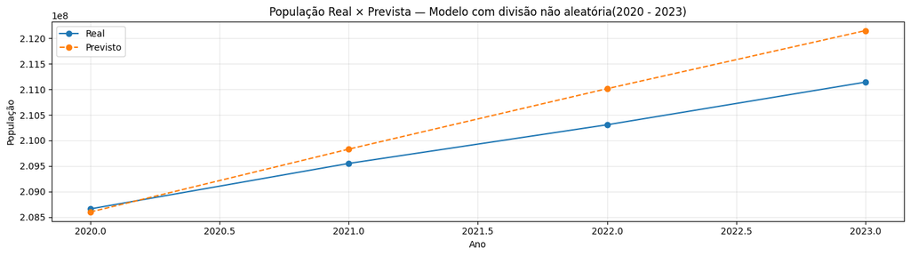

```python
plt.figure(figsize=(14, 4))

plt.plot(
    resultado_residuos["ano"],
    resultado_residuos["real"],
    marker="o",
    label="Real",
)

plt.plot(
    resultado_residuos["ano"],
    resultado_residuos["previsto"],
    marker="o",
    linestyle="--",
    label="Previsto",
)

plt.title("População Real × Prevista — Modelo com divisão não aleatória(2020 - 2023)")
plt.xlabel("Ano")
plt.ylabel("População")
plt.legend()
plt.grid(True, alpha=0.3)

plt.tight_layout()
plt.show()
```

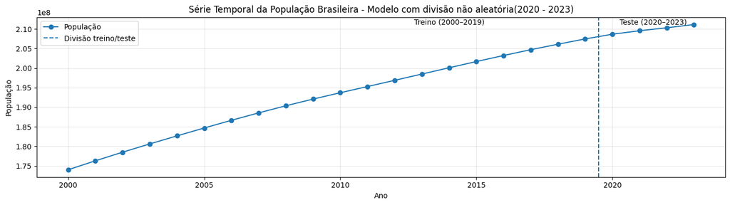

```python
plt.figure(figsize=(14, 4))

plt.plot(
    df["ano"],
    df["valor"],
    marker="o",
    label="População",
)

plt.axvline(
    x=2019.5,
    linestyle="--",
    label="Divisão treino/teste",
)

plt.text(
    2014,
    df["valor"].max(),
    "Treino (2000–2019)",
    ha="center",
)

plt.text(
    2021.5,
    df["valor"].max(),
    "Teste (2020–2023)",
    ha="center",
)

plt.title("Série Temporal da População Brasileira - Modelo com divisão não aleatória(2020 - 2023)")
plt.xlabel("Ano")
plt.ylabel("População")
plt.legend()
plt.grid(True, alpha=0.3)

plt.tight_layout()
plt.show()
```

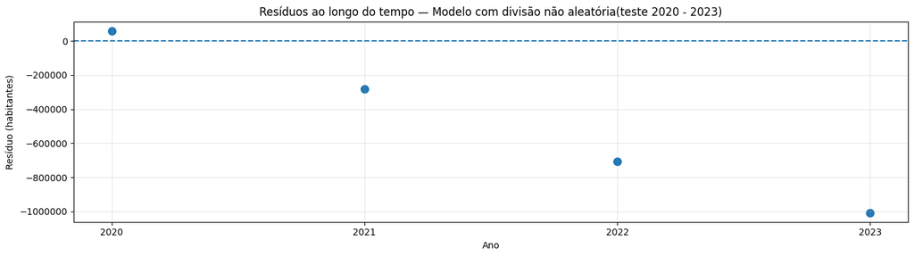

```python
# Previsões no conjunto de teste
y_pred_test = modelo.predict(X_test)

# Resíduos
residuos = y_test - y_pred_test

plt.figure(figsize=(14, 4))

plt.scatter(
    X_test["ano"],
    residuos,
    s=70,
)

plt.axhline(
    y=0,
    linestyle="--",
)

plt.xlabel("Ano")
plt.ylabel("Resíduo (habitantes)")
plt.title("Resíduos ao longo do tempo — Modelo com divisão não aleatória(teste 2020 - 2023)")

plt.xticks([2020, 2021, 2022, 2023])
plt.ticklabel_format(
    style="plain",
    axis="y",
)

plt.grid(True, alpha=0.3)
plt.tight_layout()
plt.show()
```

## 📑 9.3 Previsão para 2026 — Modelo com Divisão não Aleatória

```python
ano_futuro = pd.DataFrame({
    "ano": [2026],
})

y_pred_2026 = modelo.predict(ano_futuro)

print(
    f"População estimada para 2026: ",
    f"{y_pred_2026[0]:,.0f}".replace(",", ".")
)
```

```
População estimada para 2026:  215.277.821
```

O gráfico de resíduos do conjunto de teste, correspondente ao período de 2020 a 2023, apresenta um padrão claramente decrescente. O resíduo foi positivo em 2020, aproximadamente 60 mil habitantes, e tornou-se progressivamente mais negativo nos anos seguintes, atingindo aproximadamente −1,01 milhão de habitantes em 2023. Esse comportamento indica que o modelo passou a superestimar sistematicamente a população nos anos mais recentes.

A presença desse padrão temporal sugere que a regressão polinomial de segundo grau com valores temporais não aleatórios não está capturando completamente a dinâmica observada no período de teste. Dessa forma, embora o modelo apresente excelente ajuste aos dados históricos, seu comportamento fora da amostra revela uma limitação importante para previsões futuras.

## ✅ 10. Comparação final - Modelo com Divisão aleatória e não Aleatória

Comparação entre Regressão Polinomial com valores temporais aleatórios e não aleatórios, respectivamente.

A regressão polinomial apresentou excelente ajuste quando os dados foram divididos aleatoriamente, com R² de 0,9997 no conjunto de teste. Entretanto, essa abordagem não representa adequadamente um cenário de previsão temporal, pois permite que observações de anos posteriores participem do treinamento.

Na regressão polinomial com divisão não aleatória, utilizando 2000–2019 para treinamento e 2020–2023 para teste, o R² caiu para aproximadamente 0,52. Embora os erros percentuais tenham permanecido relativamente baixos, os resíduos apresentaram comportamento progressivamente negativo, indicando que o modelo passou a superestimar a população nos anos mais recentes.

Dessa forma, enquanto o modelo com divisão aleatória alcançou uma aproximação muito boa no que diz respeito aos números reais de habitantes para o ano de 2026; o modelo com divisão não aleatória fornece uma avaliação mais realista da capacidade de generalização do modelo, dada a divisão mais adequada para uma série temporal, mesmo não alcançando uma boa aproximação. A previsão de 2026 deve ser interpretada como uma estimativa experimental, e não como uma projeção demográfica oficial..